# Washington-Registered Electic Vehicles Analysis

Syed Naqvi - 100590852

02 April, 2024

# Introduction

The purpose of this analysis was to explore the distribution of electric vehicles registered in the American state of Washington. We will be exploring manufacturers and models with the greatest market-share in the state, top performing models in terms of their range and the overall distribution of Teslas as they currently dominate the EV market.

The dataset used is called ‘Electric Vehicle Population Data’ and is provided by the Washington State department of Licensing. Findings should reflect most recent conditions as data and metadata were both updated March 12th, 2024.

## Initializing Environment and Loading Data

```r
### INITIALIZING ###
  graphics.off()
  rm(list=ls())
  map_packages <- c("ggrepel", "patchwork", "socviz", "tidyverse", "ggthemes", "tidygeocoder", "sf", "ozmaps", "maps", "mapdata", "mapproj", "rmapshaper", "devtools")
  lapply(map_packages, library, character.only=TRUE)
```

[output not shown]

[output cut: 28 more lines]

[output not shown]

```r
### DATA CLEANING ###

  # loading the main dataset
  raw <- read_csv("./Electric_Vehicle_Population_Data.csv") |>
    as_tibble()
  # Extracting primary analysis data
  d <- raw |>
    as_tibble() |>
    select(c("Model Year", "Make", "Model",
             "Electric Range")) |>
    rename(make = Make, model = Model, modelYear = 'Model Year', range = 'Electric Range')
```

# Graphic Analysis 1

## Plot 1 - Vehicle Distribution by Manufacturer

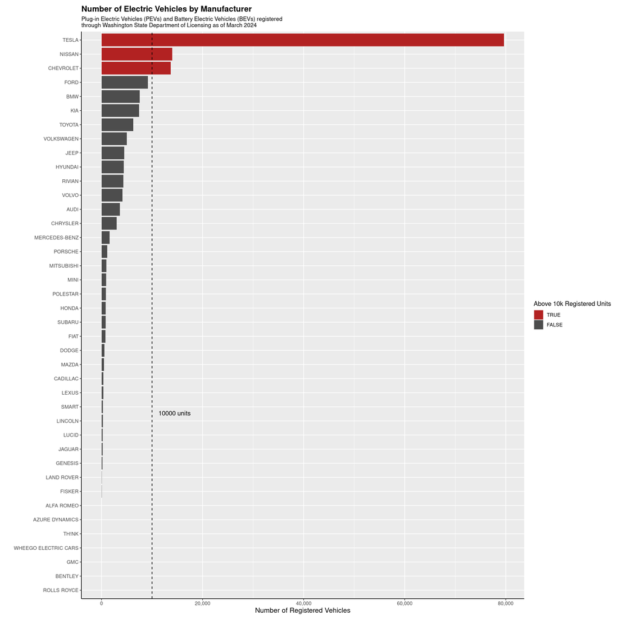

```r
# R code to generate the first plot\

## Histogram counting the number of EV's by make ##
  # preliminary data manipulation and tidying
  make_count <- d |>
    count(make, name = "count") |>
    arrange(desc(count)) |>
    mutate(over_10k = count > 10000)

  # generating the histogram
  make_hist <- make_count |>
    ggplot() +
    geom_col(aes(x = count,
                 y = reorder(make, count),
                 fill = over_10k)) +
    labs(title = "Number of Electric Vehicles by Manufacturer",
         subtitle = paste(
           "Plug-in Electric Vehicles (PEVs) and Battery Electric Vehicles (BEVs) registered",
           "through Washington State Department of Licensing as of March 2024", sep = "\n"),
         x = "Number of Registered Vehicles",
         y = "") +
    scale_fill_manual(values = c("TRUE" = "firebrick", "FALSE" = "grey30"),
                      name = "Above 10k Registered Units") +
    scale_x_continuous(
      breaks = c(seq(0, 80000, by = 20000)),
      minor_breaks = c(seq(0, 80000, by = 10000)),
      labels = c("0", "20,000", "40,000", "60,000", "80,000" )
    ) +
    theme(
      axis.line.x.bottom = element_line(linewidth = 0.5, colour = "black"),
      axis.line.y.left = element_line(linewidth = 0.5, colour = "black"),
      axis.title.y = element_text(size = 12),
      axis.title.x = element_text(size = 12),
      plot.title = element_text(size = 14, face = "bold"),
      plot.subtitle = element_text(size = 10),
      plot.margin = margin(b=10, r=10, l=10, t=10, unit = "pt")
    ) +
    geom_vline(xintercept = 10000, linetype = "dashed", color = "black", linewidth = 0.5) +  # Add vertical line
    annotate("text", x = 10000, y = 5, label = "10000 units", color = "black", hjust = -0.2, vjust = -25) +  # Add label for the line
    guides(fill = guide_legend(reverse = TRUE))
  print(make_hist)
```

## Plot 2 - Average Vehicle Range by Manufacturer

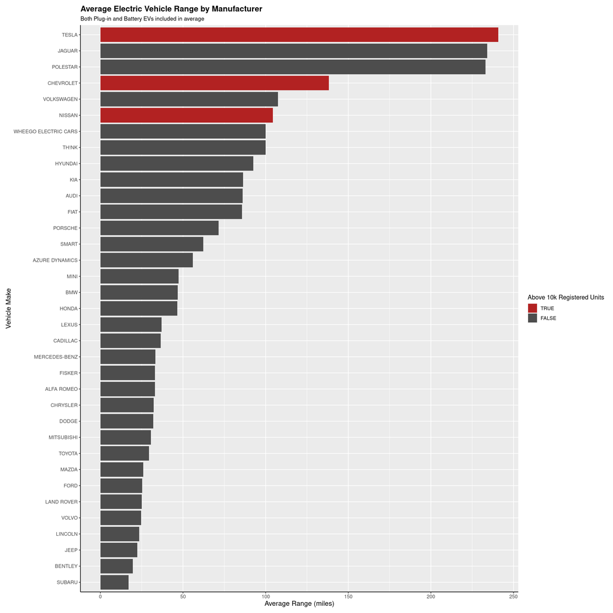

```r
## Bar plot visualizing average EV range by manufacturer
  # this vector will store the top three most frequent vehicle makes
  above_10k_units <- make_count$make[1:3]

  # constructing new tibble for average range plot
  make_range <- d |>
    filter(!(range == 0)) |>
    group_by(make) |>
    summarise(avg_range = mean(range, na.rm = TRUE)) |>
    arrange(desc(avg_range)) |>
    mutate(over_10k = if_else(make %in% above_10k_units, TRUE, FALSE))

  # generating plot
  make_range_bar <- make_range |>
    ggplot() +
    geom_col(aes(x = avg_range,
                 y = reorder(make, avg_range),
                 fill = over_10k)) +
    labs(title = "Average Electric Vehicle Range by Manufacturer",
         subtitle = "Both Plug-in and Battery EVs included in average",
         x = "Average Range (miles)",
         y = "Vehicle Make") +
    scale_fill_manual(values = c("TRUE" = "firebrick", "FALSE" = "grey30"),
                      name = "Above 10k Registered Units") +
    theme(
      axis.line.x.bottom = element_line(linewidth = 0.5, colour = "black"),
      axis.line.y.left = element_line(linewidth = 0.5, colour = "black"),
      axis.title.y = element_text(size = 12),
      axis.title.x = element_text(size = 12),
      plot.title = element_text(size = 14, face = "bold"),
      plot.subtitle = element_text(size = 10),
      plot.margin = margin(b=10, r=10, l=10, t=10, unit = "pt")
    ) +
    guides(fill = guide_legend(reverse = TRUE))
  print(make_range_bar)
```

## Plot 2 - Discussion

It seemed plausible that EVs with better performance in range would likely be more sought after leading to more registered units. The second graphic explores just this relation and we do find that the top three manufacturers in terms of registered vehicles have above 100 miles of average range across their models placing them among the top 6 manufacturers for range.

# Graphic Analysis 2

## Plot 3 - Change in EV Range by Model and Manufacturer

```r
# extracting and summarizing records for only these manufacturers
  long_range_data <- d |>
    filter((make %in% c("TESLA", "NISSAN", "CHEVROLET")),  !(range == 0)) |>
    group_by(make, model, modelYear) |>
    summarize(avg_range = mean(range, na.rm = TRUE))
```

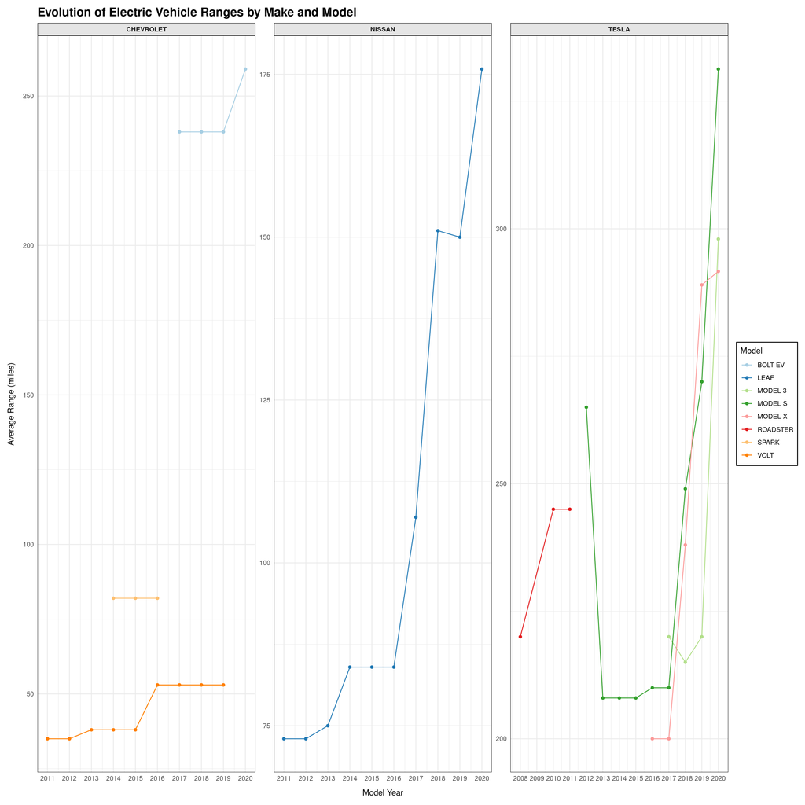

```r
  # finding models with only a single entry
  single_entry <- long_range_data |>
    count(model, name = "modelcount") |>
    filter(modelcount == 1) |>
    ungroup() |>
    pull(model)

  # removing records with the single entry model
  long_range_data <- long_range_data |>
    filter(!(model %in% single_entry))

  #creating faceted plots where the points are connected by grouped lines
  range_plot <- long_range_data |>
    ggplot(aes(x = modelYear, y = avg_range)) +
    geom_line(aes(group = model, color = model)) +
    geom_point(aes(group = model, color = model)) +
    facet_wrap(~make, scales = "free") +
    labs(
      title = "Evolution of Electric Vehicle Ranges by Make and Model",
      x = "Model Year",
      y = "Average Range (miles)",
      colour = "Model"
    ) +
    scale_x_continuous(breaks = function(x) seq(floor(min(x)), ceiling(max(x)), by = 1)) +
    scale_color_brewer(palette = "Paired") +
    theme_minimal() +
    theme(
      plot.margin = margin(t=10, b=10, r=10, l=10, unit = "pt"),

      panel.border = element_rect(colour = "black", fill=NA, linewidth=0.4),

      axis.title.x = element_text(margin = margin(t=10, unit = "pt")),
      axis.title.y = element_text(margin = margin(r=10, unit = "pt")),
      plot.title = element_text(size = 16, face = "bold"),

      strip.background = element_rect(fill = "grey90"),
      strip.text.x = element_text(face = "bold"),
      legend.background = element_rect(fill = "white")
    )
  range_plot
```

## Plot 3 - Discussion

With this plot, the goal was to understand changes in EV range over multiple model iterations. The choice was made to consider again, the top three most numerous manufacturers as they were also amongst the brands with the longest range and seemed likely to provide more extensive information regarding their various EV models. Models with only one iteration were removed from the data as improvements or deteriorations could not be observed. We found that nearly all models saw either range stagnation or improvement over time other than the Tesla models S and 3 who initially saw decreases in range but eventually made improvements.

# Graphic Analysis 3

## Plot 4 - Proportion of Registered EV Models

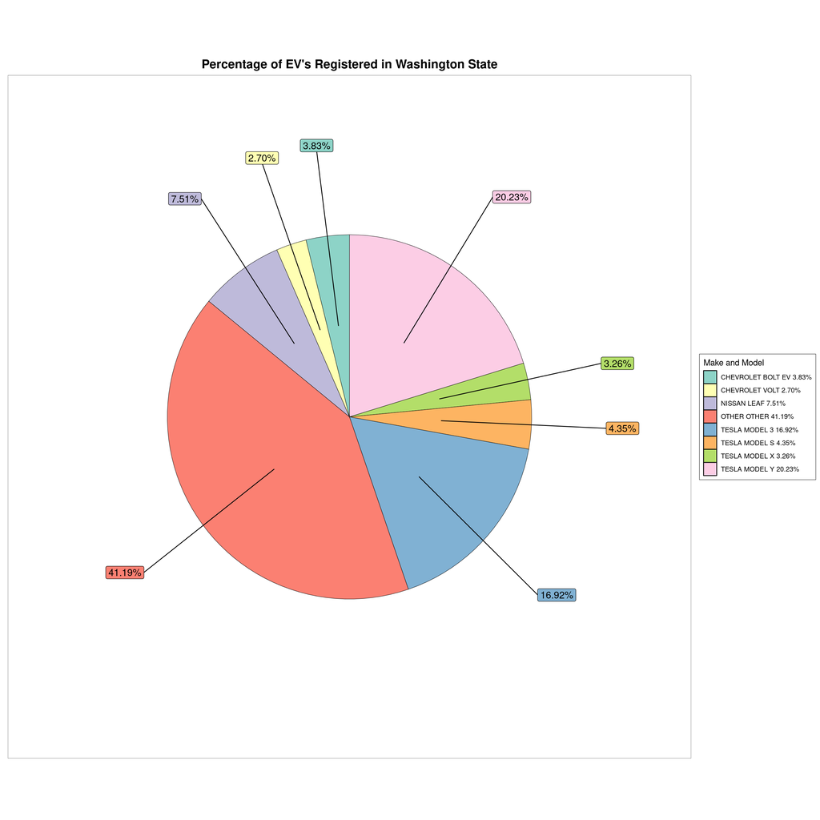

```r
  # Total number of vehicles
  total_vehicles <- nrow(d)

  # Top 7 most numerous models
  numerous_makes <- d |>
    count(make, model) |>
    arrange(desc(n)) |>
    slice(1:7)

  # Sum the counts of the top 7 makes/models
  top_vehicles_count <- sum(numerous_makes$n)

  # Calculate the count for "OTHER"
  other_vehicles <- total_vehicles - top_vehicles_count

  # Combine the top 7 with "OTHER" and calculate percentages
  model_percentages <- numerous_makes |>
    ungroup() |>
    add_row(make = "OTHER", model = "OTHER", n = other_vehicles) |>
    mutate(percentage = n / total_vehicles) |>
    mutate(model = paste(make, model, scales::percent(percentage), sep = " "))

# creating a pie chart of the above data

  # Calculate label positions
  model_percentages <- model_percentages |>
    arrange(desc(model)) |>
    mutate(cumsum = cumsum(percentage),
           pos = cumsum - percentage / 2,
           label = scales::percent(percentage))

  # Create the pie chart
  pie_chart <- ggplot(model_percentages, aes(x = "", y = percentage, fill = model)) +
    geom_col(width = 1, colour = "black", linewidth = 0.2) +
    coord_polar(theta = "y") +
    scale_fill_brewer(palette = "Set3") +
    geom_label_repel(
      aes(y = pos, label = label),
      size = 4.5,
      nudge_x = 1,
      show.legend = FALSE
    ) +
    theme_minimal() +
    theme(
      legend.key = element_rect(colour = "black"),
      plot.title = element_text(size = 16, face = "bold", hjust = 0.5),
      axis.title.x = element_blank(),
      axis.title.y = element_blank(),
      axis.text.x = element_blank(),
      panel.border = element_rect(colour = "black", linewidth = 0.2, fill = NA),
      panel.grid = element_blank(),
      legend.background = element_rect(fill = "grey100", colour = "black", linewidth = 0.2)) +
    labs(fill = "Make and Model", title = "Percentage of EV's Registered in Washington State")

  # Display the pie chart
  pie_chart
```

## Plot 4 - Discussion

Extracting the top seven most numerous models as opposed to manufacturers allowed us to view the EV distribution through a different lens. We can see that Telsa models as expected comprise of more EVs than the entire OTHER section. Also as expected, Nissan and Chevrolet occupy their familiar second and third place roles as single brands. We have also found that Tesla Model Y is the most registered EV in the state of Washington.

# Graphic Analysis 4

## Plot 5 - Geospatial Distribution of Teslas Across the US

```r
   # Extracting extracting state and county information from raw dataset
  mapping <- raw |>
    select("State",Make) |>
    rename(make = Make, abb = "State")

  # creating a simple state name to state abbreviation mapping
  state_mapping <- tibble(abb = state.abb,
                          name = state.name)

  # creating a tibble with the vehicle make and the state
  mapping <- mapping |>
    left_join(state_mapping, join_by(abb)) |>
    mutate(name = tolower(name)) |>
    select(make, name)

  # creating a simple feature object from US county data
  d_state = st_as_sf(maps::map('state', plot = FALSE, fill = TRUE))

  # using d_state and the mapping dataset to create an sf object for TESLAs distributed throughout the us
  mapping <- mapping |>
    mutate(make = ifelse(make == "TESLA", 1, 0)) |>
    inner_join(d_state, join_by(name == ID)) |>
    group_by(name, geom) |>
    summarise(n = sum(make), .groups = "drop")

  # Create the base map with correct legend scaling
  p <- ggplot() +
    theme_map() +
    geom_sf(data = mapping, aes(fill = n, geometry = geom), colour = "grey") +
    scale_fill_gradientn(colors = c("white", "red"),
                         trans = "log1p",
                         breaks = c(1, 10, 100, 1000, 10000),
                         labels = c("1", "10", "100", "1k", "10k")) +
    coord_sf(crs = st_crs(4326)) +
    theme(legend.position = "bottom",
          legend.direction = "horizontal",
          legend.key.width = unit(1.5, "cm"),
          plot.title = element_text(size = 16, face = "bold")) +
    labs(title = "Distribution of Washington-Registered Teslas in the US by State", fill = "Number of Teslas")

  # Adding the state boundaries
  p <- p +
    geom_sf(data = d_state, fill = NA, colour = "grey30", linewidth = 0.35)
```

[output not shown]

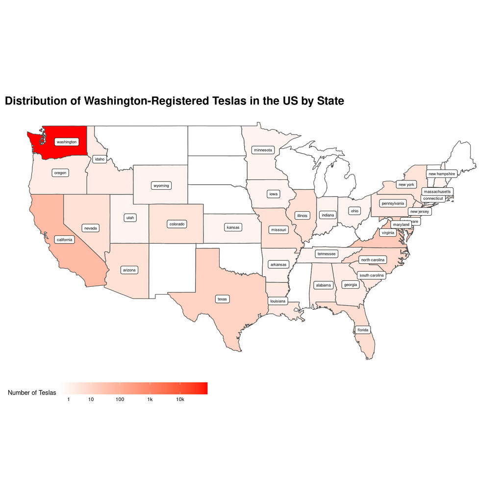

```r
  # Add labels only for states with Teslas
  d_state_with_teslas <- d_state |>
    inner_join(mapping |>  filter(n > 0), by = c("ID" = "name"))

  p <- p +
    geom_sf_label(data = d_state_with_teslas, aes(label = ID), nudge_x = 0.1, nudge_y = 0.1, size = 2) +
    theme(axis.title = element_blank())

  # Print the map
  print(p)
```

# References

### Dataset Download Page

- https://catalog.data.gov/dataset/electric-vehicle-population-data

### Dataset Main Information Page

- https://data.wa.gov/Transportation/Electric-Vehicle-Population-Data/f6w7-q2d2/about_data